# hw6

# 2.26

## (a)

```r
X <- c(16, 16, 16, 16, 24, 24, 24, 24,
       32, 32, 32, 32, 40, 40, 40, 40)
Y <- c(199, 205, 196, 200, 218, 220, 215, 223,
       237, 234, 235, 230, 250, 248, 253, 246)
n <- 16
b1 <- sum((X-mean(X))*(Y-mean(Y)))/sum((X-mean(X))^2)
b0 <- mean(Y)-mean(X)*b1
Y_hat <- b0+b1*X
sse <- sum((Y-Y_hat)^2)
sse
```

```
## [1] 146.425
```

```r
ssr <- sum((Y_hat-mean(Y))^2)
ssr
```

```
## [1] 5297.512
```

```r
ssto <- sse + ssr
ssto
```

```
## [1] 5443.937
```

ANOVA Table

[output not shown]

## (b)

$H_0:\beta_1=0$ (there is no association between X and Y)

$H_a:\beta_1\neq0$ (there is linear association between X and Y)

$F^{\ast}=MSR/MSE$

Decision rule:

If $F^{\ast}\le{F(1-\alpha;1,n-2)}$, conclude $H_0$

If $F^{\ast}>{F(1-\alpha;1,n-2)}$, conclude $H_a$

```r
msr <- ssr
mse <- sse/(n-2)
ftest <- msr/mse
ftest
```

```
## [1] 506.5062
```

$F^{\ast}=506.5>F(1-0.01;1,14)=8.862$

We conclude $H_a$, there is a linear association.

## (c)

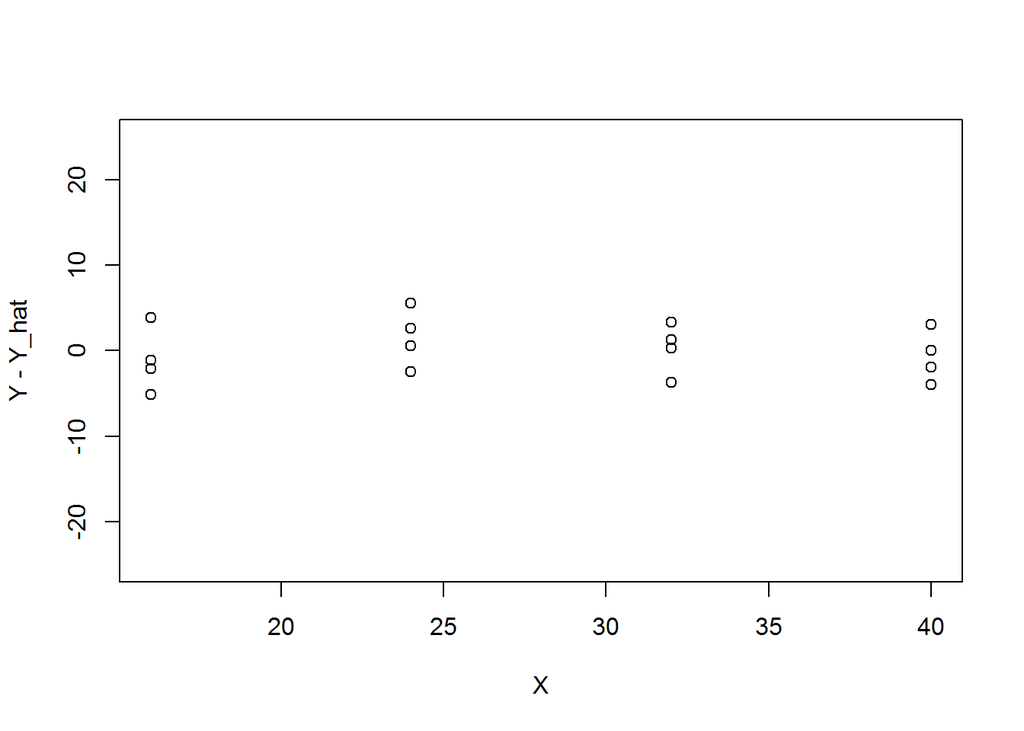

```r
plot(X, Y-Y_hat, ylim=c(-25, 25))
```

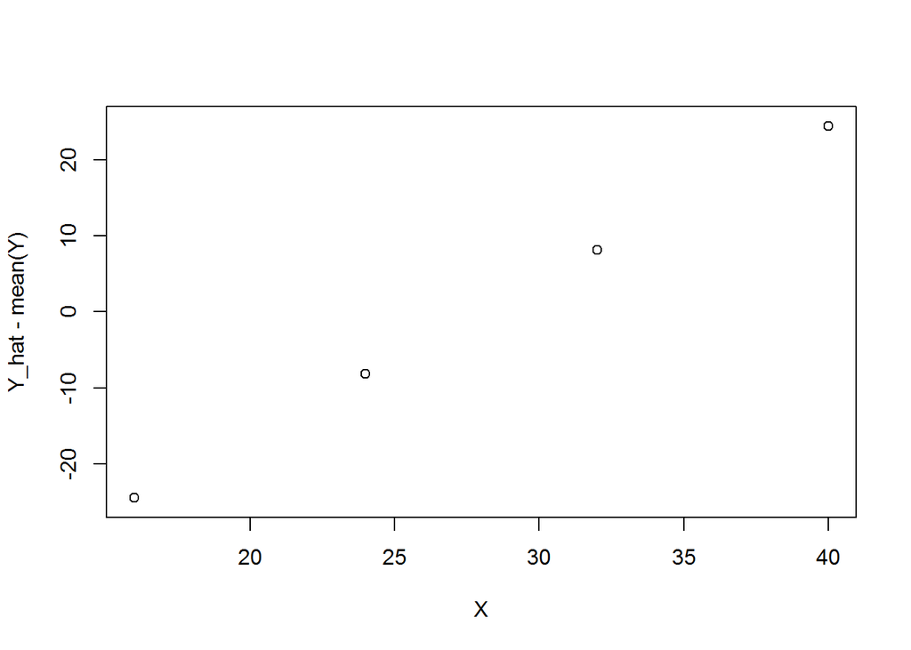

```r
plot(X, Y_hat-mean(Y), ylim=c(-25, 25))
```

SSR is the larger component of SSTO It means $R^2$ is close to 1

## (d)

```r
r_sq <- ssr/ssto
r_sq
```

```
## [1] 0.9731031
```

```r
correlation <- sqrt(r_sq)
correlation
```

```
## [1] 0.9864599
```

$R^2=0.9731$

$r=0.9865$

# 2.41

No. X here is fixed, not a random variable. Spearman Rank Correlation Coefficient (RHO) is used for two random variables Y1 and Y2 whose joint distribution differ considerably from bivariate normal distribution. So it’s not useful here.

# 3.14

## (a)

j is the index for different level of X, i is the index for different replicas at the same level of X

$H_0:Y_{ij}=\beta_0+\beta_1X_j+\epsilon_{ij}$ (linear model is a good fit for the data)

$H_a:Y_{ij}=\mu_j+\epsilon_{ij}$ (linear model is not a good fit, more complex model is needed)

Decision rule:

If $F^{\ast}\le{F(1-\alpha;c-2,n-c)}$, conclude $H_0$

If $F^{\ast}>{F(1-\alpha;c-2,n-c)}$, conclude $H_a$

```r
Y1 <- c(199, 205, 196, 200)
Y2 <- c(218, 220, 215, 223)
Y3 <- c(237, 234, 235, 230)
Y4 <- c(250, 248, 253, 246)
sspe <- sum((Y1-mean(Y1))^2)+sum((Y2-mean(Y2))^2)+sum((Y3-mean(Y3))^2)+sum((Y4-mean(Y4))^2)
c <- 4
ftest_fit <- ((sse-sspe)/(c-2))/(sspe/(n-c))
ftest_fit
```

```
## [1] 0.8236893
```

$F^{\ast}=0.8237<F(0.01; 2, 12)=6.927$

We conclude $H_0$, linear model is a good fit.

## (b)

Equal number of replicas is advantageous, because it makes each level of X equally important. But if we know the relation is linear, assigning more samples at extreme points will increase the power of the test.

## (c)

No, lack of fit test doesn’t indicate what regression function is appropriate. One apporach is using a more complex model, such as quadratic regression function or logarithmic regression. We can plot the residuals to see which function is best.

# 6.9

## (a)

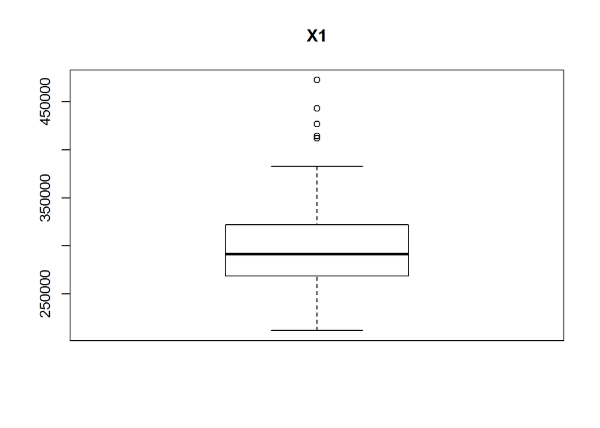

```r
library(ggplot2)
retails <- read.table("https://netfiles.umn.edu/users/nacht001/www/nachtsheim/5th/KutnerData/Chapter%20%206%20Data%20Sets/CH06PR09.txt", col.names=c("Y", "X1", "X2", "X3"))

X1 <- retails$X1
X2 <- retails$X2
X3 <- retails$X3

Y <- retails$Y

boxplot(X1, main="X1")
```

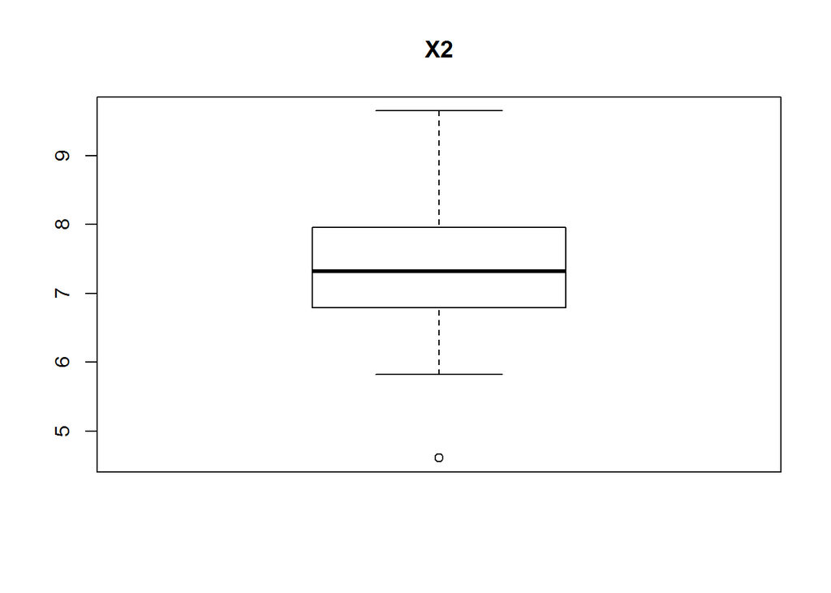

```r
boxplot(X2, main="X2")
```

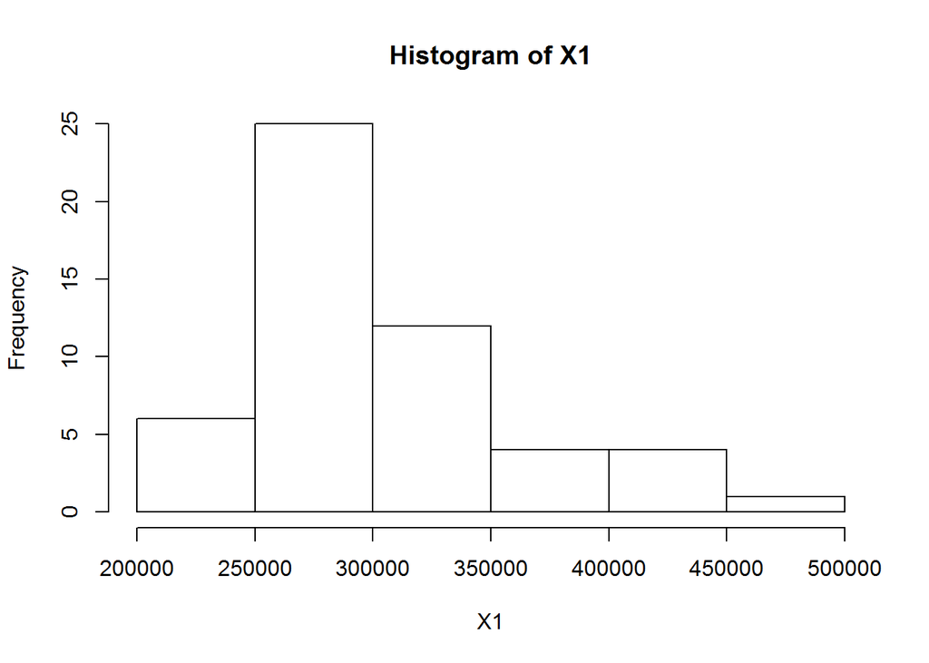

```r
hist(X1)
```

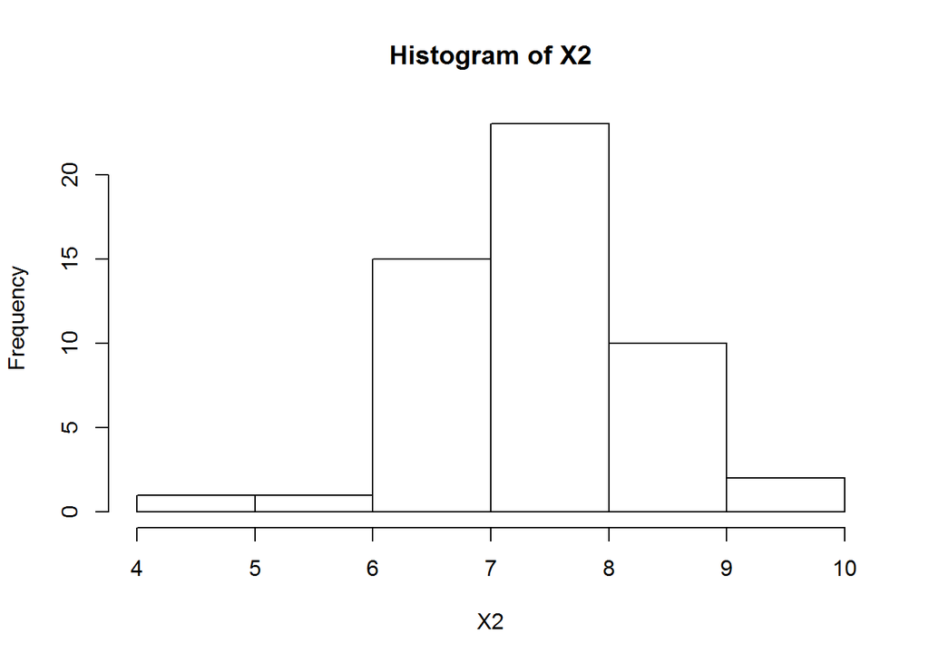

```r
hist(X2)
```

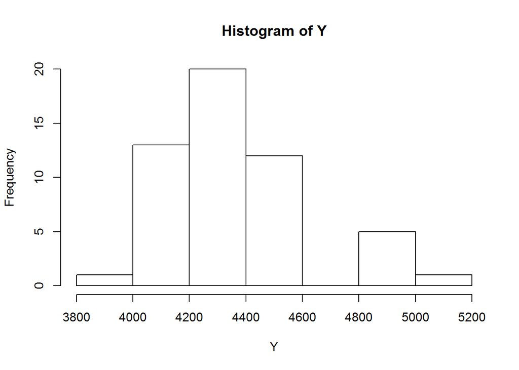

```r
hist(Y)
```

We can see from the boxplots that there are outliers in X1 and X2.

From the histgraph, we can see there is a gap (4600-4800) in Y.

## (b)

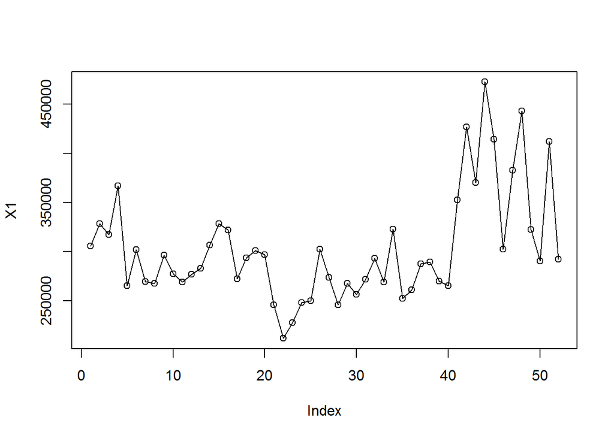

```r
plot(X1, type="o")
```

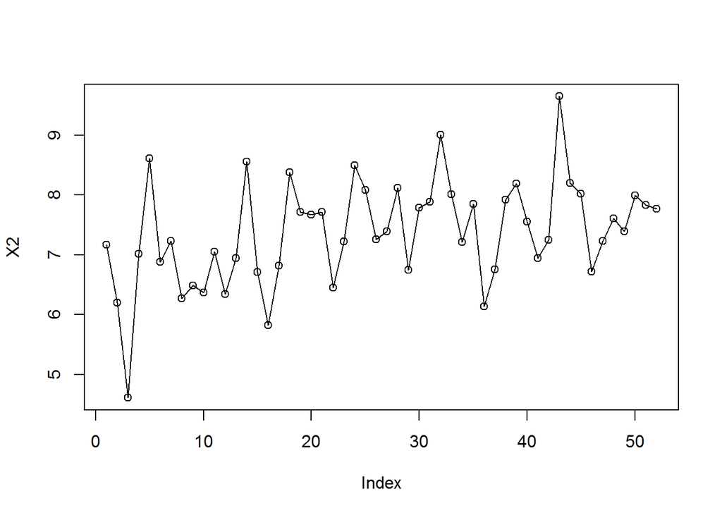

```r
plot(X2, type="o")
```

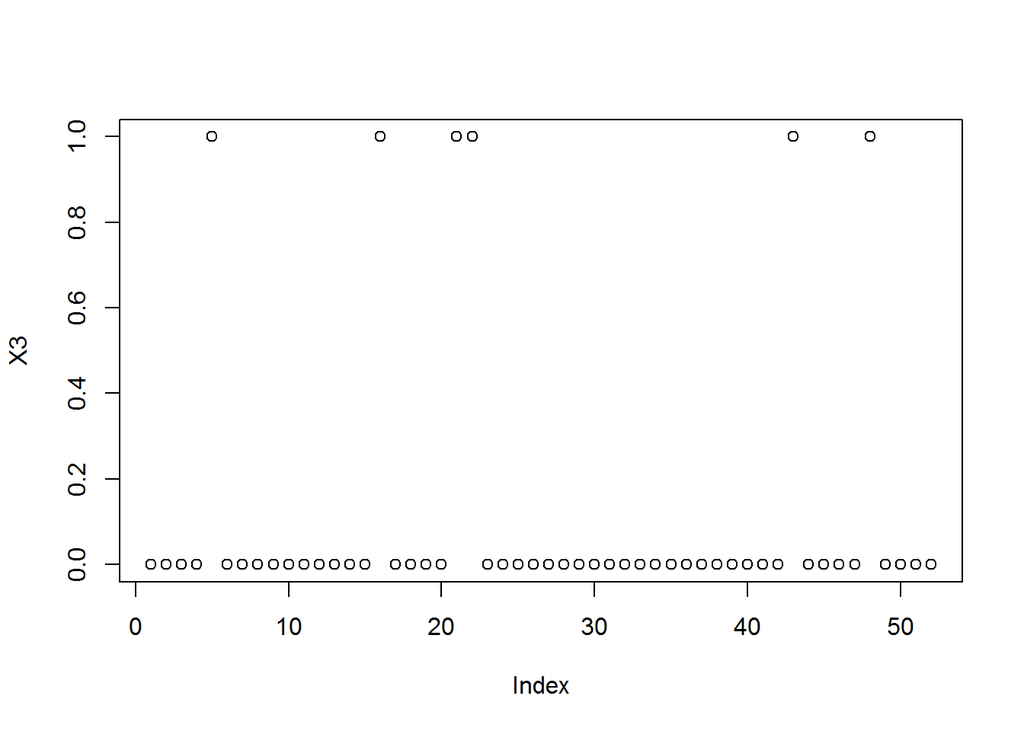

```r
plot(X3, type="p")
```

X1 decreases from week 0-20, then increases from week 20-40, and reaches highest from week 40-50.

For X2, there seem to be cycles every 5-6 weeks, and a general trend of increase throughout the year.

## (c)

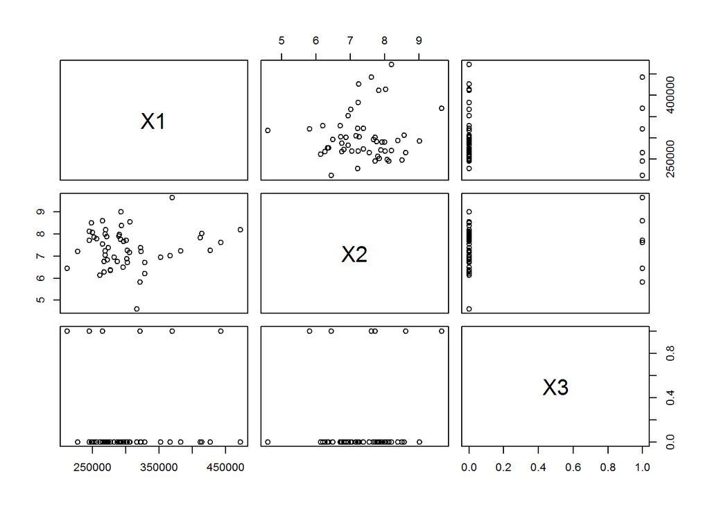

```r
pairs(retails[, 2:4])
```

```r
cor(retails[, 2:4])
```

```
##            X1         X2         X3
## X1 1.00000000 0.08489639 0.04565698
## X2 0.08489639 1.00000000 0.11337076
## X3 0.04565698 0.11337076 1.00000000
```

From the scatter plot matrix and correlation matrix, we can see there isn’t much correlation between predictor variables.

# 6.10

## (a)

```r
fit <- lm(Y ~ X1 + X2 + X3)
summary(fit)
```

```
##
## Call:
## lm(formula = Y ~ X1 + X2 + X3)
##
## Residuals:
##     Min      1Q  Median      3Q     Max
## -264.05 -110.73  -22.52   79.29  295.75
##
## Coefficients:
##               Estimate Std. Error t value Pr(>|t|)
## (Intercept)  4.150e+03  1.956e+02  21.220  < 2e-16 ***
## X1           7.871e-04  3.646e-04   2.159   0.0359 *
## X2          -1.317e+01  2.309e+01  -0.570   0.5712
## X3           6.236e+02  6.264e+01   9.954 2.94e-13 ***
## ---
## Signif. codes:  0 '***' 0.001 '**' 0.01 '*' 0.05 '.' 0.1 ' ' 1
##
## Residual standard error: 143.3 on 48 degrees of freedom
## Multiple R-squared:  0.6883, Adjusted R-squared:  0.6689
## F-statistic: 35.34 on 3 and 48 DF,  p-value: 3.316e-12
```

```r
b0 <- fit$coefficients[1]
b0
```

```
## (Intercept)
##    4149.887
```

```r
b1 <- fit$coefficients[2]
b1
```

```
##           X1
## 0.0007870804
```

```r
b2 <- fit$coefficients[3]
b2
```

```
##        X2
## -13.16602
```

```r
b3 <- fit$coefficients[4]
b3
```

```
##       X3
## 623.5545
```

$Y_{hat}=4149.89+0.000787X_1-13.166X_2+623.55X_3$

b1 is the change of E{Y} with a unit increase in $X_1$ when $X_2$ and $X_3$ are held constant

b2 is the change of E{Y} with a unit increase in $X_2$ when $X_1$ and $X_3$ are held constant

b3 is the change of E{Y} with a unit increase in $X_3$ when $X_1$ and $X_2$ are held constant

## (b)

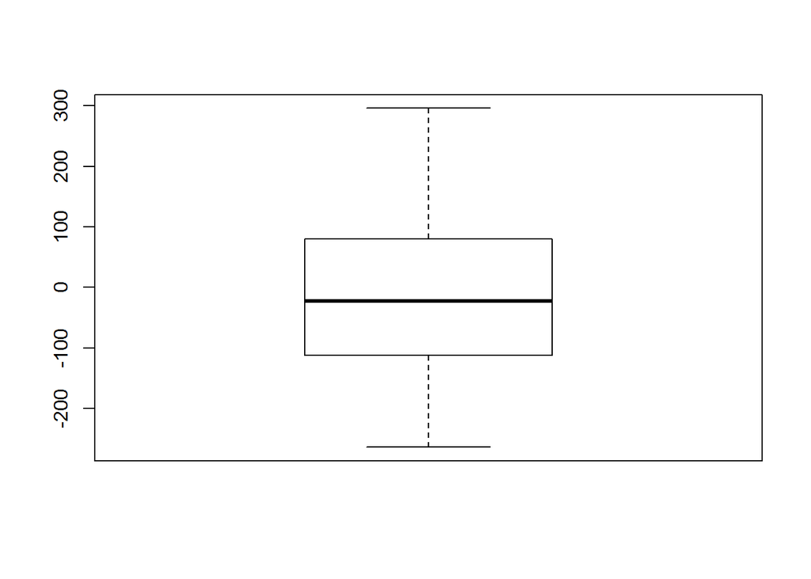

```r
resid <- resid(fit)
boxplot(resid)
```

From the boxplot we can see that the residuals are not skewed, and there are no outliers.

## (c)

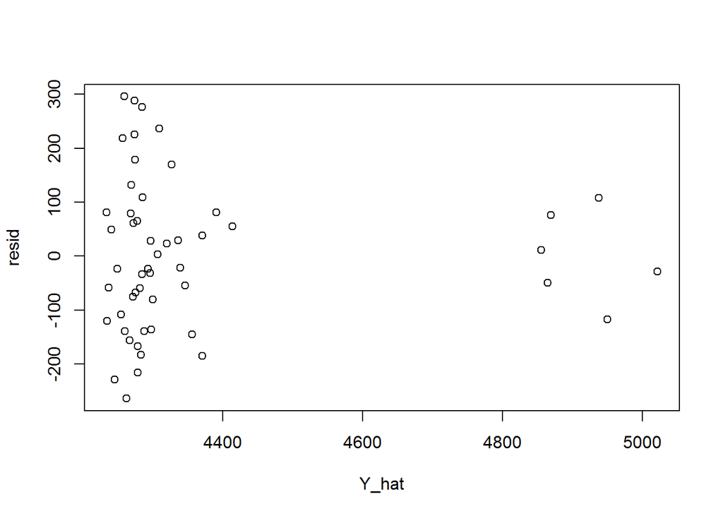

```r
Y_hat <- b0+b1*X1+b2*X2+b3*X3
plot(Y_hat, resid)
```

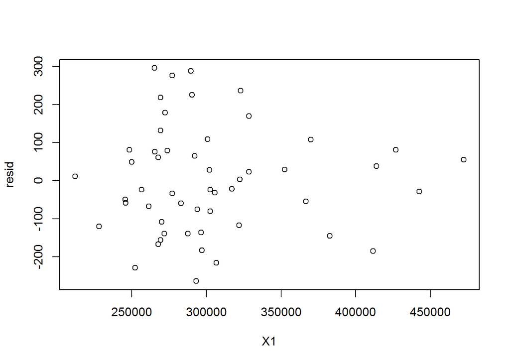

```r
plot(X1, resid)
```

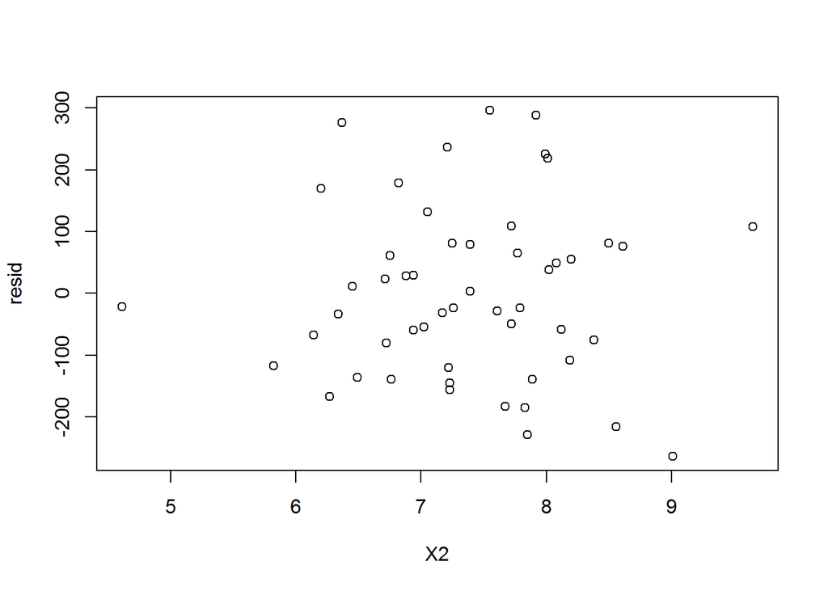

```r
plot(X2, resid)
```

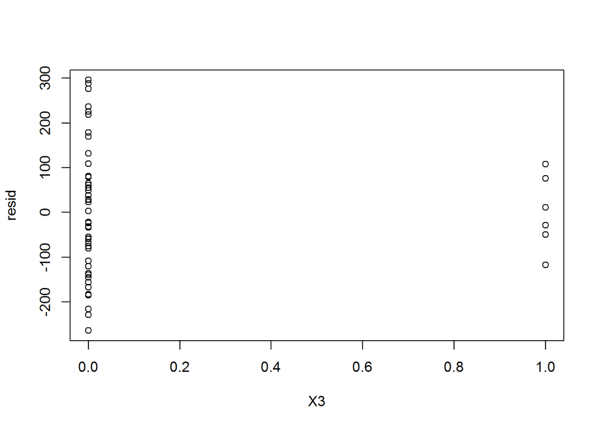

```r
plot(X3, resid)
```

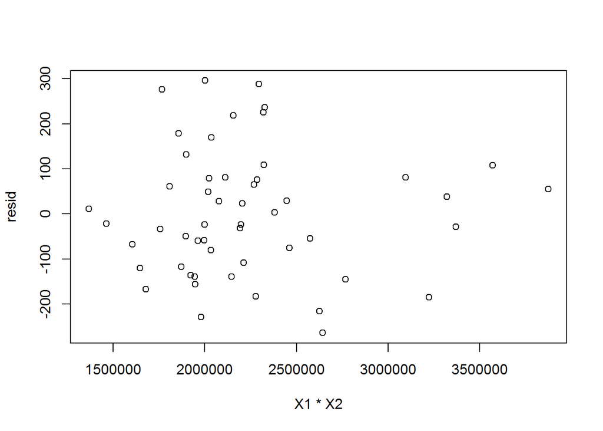

```r
plot(X1*X2, resid)
```

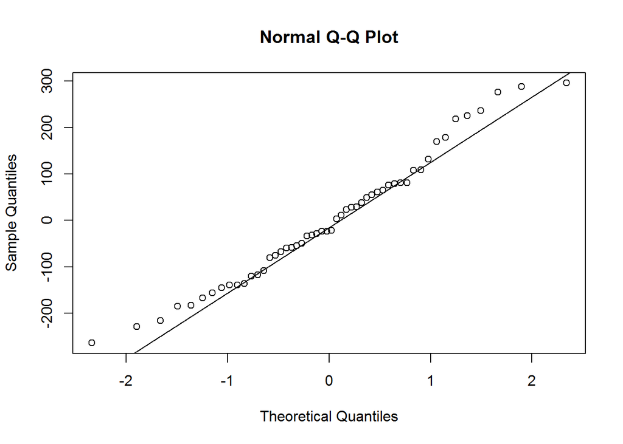

```r
qqnorm(resid)
qqline(resid)
```

It looks like there’s no systematic error, residuals have 0 mean. residual variance is larger when X1 is small, but there are more samples with small X1, that could explain the variance. From quantile-quantile plot, it looks like residuals are close to normal distribution.

## (d)

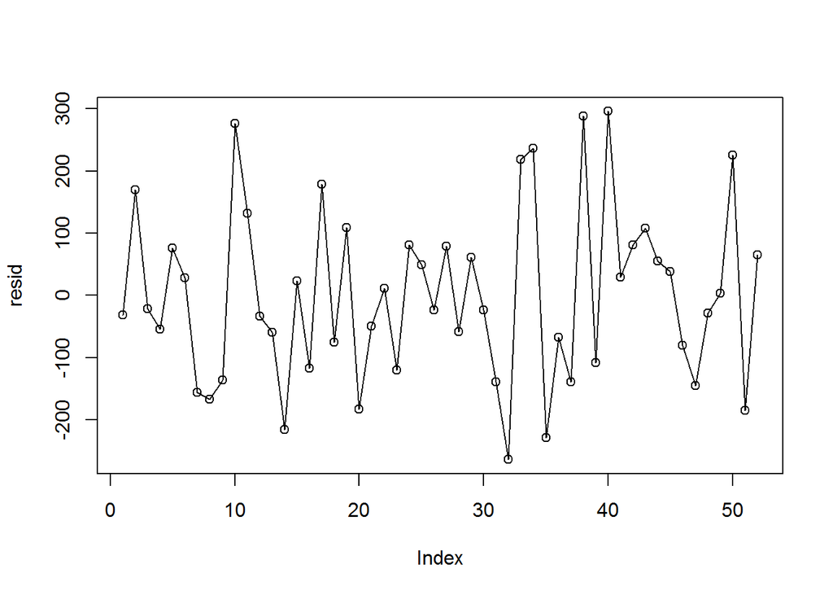

```r
plot(resid, type="o")
```

The residuals seem to be independent, there isn’t any indication that the error terms are correlated.

# 6.11

## (a)

$H_0:\beta_1=\beta_2=\beta_3=0$

$H_a:$ at least one of $\beta_1,\beta_2,\beta_3$ is not zero

$F^{\ast}=MSR/MSE$

Decision rule:

If $F^{\ast}\le{F(1-\alpha;p-1,n-p)}$, conclude $H_0$

If $F^{\ast}>{F(1-\alpha;p-1,n-p)}$, conclude $H_a$

```r
sse <- sum((Y-Y_hat)^2)
ssr <- sum((Y_hat-mean(Y))^2)
n <- length(Y)
p <- 4
msr <- ssr/(p-1)
mse <- sse/(n-p)
ftest <- msr/mse
ftest
```

```
## [1] 35.33703
```

$F^{\ast}=35.34>F(0.05; 3, 48)=2.8$

We conclude $H_a$, at least one of $\beta_1,\beta_2,\beta_3$ is not zero.

```r
pvalue <- pf(ftest, 3, 48, lower.tail=FALSE)
pvalue
```

```
## [1] 3.315708e-12
```

## (c)

```r
r_sq <- ssr/(ssr+sse)
r_sq
```

```
## [1] 0.6883342
```

$R^2$ here measures the proportionate reduction of total variation in Y associated with the use of the set of X variables X1, X2, X3

# 6.14

## (a)

```r
b <- c(b0, b1, b2, b3)
Xh <- matrix(c(1, 282000, 7.10, 0), nrow=1, ncol=4)
Yh <- sum(Xh*b)
bvar <- vcov(fit)
Yh_var <- Xh %*% bvar %*% t(Xh)
ttest <- qt(0.975, df=48)
predmean_var <- mse/3 + Yh_var
predmean_sd <- sqrt(predmean_var)
Yh + ttest*predmean_sd
```

```
##          [,1]
## [1,] 4450.923
```

```r
Yh - ttest*predmean_sd
```

```
##          [,1]
## [1,] 4105.807
```

95 percent prediction interval for E{Yh} is [4106, 4451]

## (b)

95 percent prediction interval for the total 3 shipments is 3*[4106, 4451]= [12318, 13353]

# 7.13

```r
ssto <- sse+ssr
fit_y_x1 <- lm(Y ~ X1)
anova(fit_y_x1)
```

```
## Analysis of Variance Table
##
## Response: Y
##           Df  Sum Sq Mean Sq F value Pr(>F)
## X1         1  136366  136366  2.2534 0.1396
## Residuals 50 3025770   60515
```

```r
fit_y_x2 <- lm(Y ~ X2)
anova(fit_y_x2)
```

```
## Analysis of Variance Table
##
## Response: Y
##           Df  Sum Sq Mean Sq F value Pr(>F)
## X2         1   11395   11395  0.1808 0.6725
## Residuals 50 3150741   63015
```

```r
fit_x1_x2 <- lm(X1 ~ X2)
anova(fit_x1_x2)
```

```
## Analysis of Variance Table
##
## Response: X1
##           Df     Sum Sq    Mean Sq F value Pr(>F)
## X2         1 1.1231e+09 1123053266   0.363 0.5496
## Residuals 50 1.5470e+11 3093930019
```

```r
fit_y_x1x2 <- lm(Y ~ X1 + X2)
anova(fit_y_x1x2)
```

```
## Analysis of Variance Table
##
## Response: Y
##           Df  Sum Sq Mean Sq F value Pr(>F)
## X1         1  136366  136366  2.2125 0.1433
## X2         1    5726    5726  0.0929 0.7618
## Residuals 49 3020044   61634
```

```r
fit_y_x1x3 <- lm(Y ~ X1 + X3)
anova(fit_y_x1x3)
```

```
## Analysis of Variance Table
##
## Response: Y
##           Df  Sum Sq Mean Sq  F value    Pr(>F)
## X1         1  136366  136366   6.7344   0.01244 *
## X3         1 2033565 2033565 100.4276 1.875e-13 ***
## Residuals 49  992204   20249
## ---
## Signif. codes:  0 '***' 0.001 '**' 0.01 '*' 0.05 '.' 0.1 ' ' 1
```

```r
fit_all <- lm(Y ~ X1 + X2 + X3)
anova(fit_all)
```

```
## Analysis of Variance Table
##
## Response: Y
##           Df  Sum Sq Mean Sq F value    Pr(>F)
## X1         1  136366  136366  6.6417   0.01309 *
## X2         1    5726    5726  0.2789   0.59987
## X3         1 2034514 2034514 99.0905 2.941e-13 ***
## Residuals 48  985530   20532
## ---
## Signif. codes:  0 '***' 0.001 '**' 0.01 '*' 0.05 '.' 0.1 ' ' 1
```

$R_{Y1}^2=\frac{SSR(X_1)}{SSTO(Y)}=\frac{136366}{3162136}=0.043$

$R_{Y2}^2=\frac{SSR(X_2)}{SSTO(Y)}=\frac{11395}{3162136}=0.0036$

$R_{12}^2=\frac{SSR(X_2)}{SSTO(X_1)}=\frac{1.1231e09}{1.1231e09+1.5470e11}=0.0072$

$R_{Y1|2}^2=\frac{SSR(X_1|X_2)}{SSE(X_2)}=\frac{SSE(X_2)-SSE(X_1,X_2)}{SSE(X_2)}=\frac{3150741-3020044}{3150741}=0.04148$

$R_{Y2|1}^2=\frac{SSR(X_2|X_1)}{SSE(X_1)}=\frac{SSE(X_1)-SSE(X_1,X_2)}{SSE(X_1)}=\frac{3025770-3020044}{3025770}=0.00189$

$R_{Y2|13}^2=\frac{SSR(X_2|X_1,X_3)}{SSE(X_1,X_3)}=\frac{SSE(X_1,X_3)-SSE(X_1,X_2,X_3)}{SSE(X_1,X_3)}=\frac{992204-985530}{992204}=0.00673$

$R^2=\frac{SSR(X_1,X_2,X_3)}{SSTO}=\frac{SSTO-SSE(X_1,X_2,X_3)}{SSTO}=\frac{2176606}{3162136}=0.6883$

# 7.17

## (a)

```r
cor_trans <- function(X){
  n <- length(X)
  sd_X <- sqrt(sum((X-mean(X))^2)/(n-1))
  X_star <- (X-mean(X))/sd_X/sqrt(n-1)
  return(X_star)
}

Y_star <- cor_trans(Y)
X1_star <- cor_trans(X1)
X2_star <- cor_trans(X2)
X3_star <- cor_trans(X3)

fit_star <- lm(Y_star ~ X1_star + X2_star + X3_star)
summary(fit_star)
```

```
##
## Call:
## lm(formula = Y_star ~ X1_star + X2_star + X3_star)
##
## Residuals:
##      Min       1Q   Median       3Q      Max
## -0.14849 -0.06227 -0.01266  0.04459  0.16632
##
## Coefficients:
##               Estimate Std. Error t value Pr(>|t|)
## (Intercept) -1.986e-16  1.117e-02   0.000   1.0000
## X1_star      1.747e-01  8.092e-02   2.159   0.0359 *
## X2_star     -4.639e-02  8.137e-02  -0.570   0.5712
## X3_star      8.079e-01  8.116e-02   9.954 2.94e-13 ***
## ---
## Signif. codes:  0 '***' 0.001 '**' 0.01 '*' 0.05 '.' 0.1 ' ' 1
##
## Residual standard error: 0.08058 on 48 degrees of freedom
## Multiple R-squared:  0.6883, Adjusted R-squared:  0.6689
## F-statistic: 35.34 on 3 and 48 DF,  p-value: 3.316e-12
```

$Y^*=0.1747X_1^*-0.04639X_2^*+0.8079X_3^*$

## (b)

```r
fit_x2_x1 <- lm(X2 ~ X1)
anova(fit_x2_x1)
```

```
## Analysis of Variance Table
##
## Response: X2
##           Df Sum Sq Mean Sq F value Pr(>F)
## X1         1  0.283 0.28296   0.363 0.5496
## Residuals 50 38.977 0.77953
```

```r
fit_x1_x3 <- lm(X1 ~ X3)
anova(fit_x1_x3)
```

```
## Analysis of Variance Table
##
## Response: X1
##           Df     Sum Sq    Mean Sq F value Pr(>F)
## X3         1 3.2482e+08  324815172  0.1044 0.7479
## Residuals 50 1.5549e+11 3109894780
```

```r
fit_x2_x3 <- lm(X2 ~ X3)
anova(fit_x2_x3)
```

```
## Analysis of Variance Table
##
## Response: X2
##           Df Sum Sq Mean Sq F value Pr(>F)
## X3         1  0.505  0.5046   0.651 0.4236
## Residuals 50 38.755  0.7751
```

$R_{12}^2=R_{21}^2=\frac{0.283}{0.283+38.977}=0.0072$

$R_{13}^2=R_{31}^2=\frac{3.2482e08}{3.2482e08+1.5549e11}=0.0021$

$R_{23}^2=R_{32}^2=\frac{0.505}{0.505+38.755}=0.0129$

Yes, it is meaningful to consider the standardized regressioin coefficient to reflect the effect of one predictor variable when the others are held constant. Since we can see from the coefficients of determination between all pairs of predictor variables, that there’s no strong correlation between any pair of predictor variables.

## (c)

```r
para <- function(Y, X, para_star){
  n <- length(X)
  sd_X <- sqrt(sum((X-mean(X))^2)/(n-1))
  sd_Y <- sqrt(sum((Y-mean(Y))^2)/(n-1))
  org_para <- para_star*sd_Y/sd_X
  return(org_para)
}
para(Y, X1, 0.1747)
```

```
## [1] 0.0007869954
```

```r
para(Y, X2, -0.04639)
```

```
## [1] -13.16565
```

```r
para(Y, X3, 0.8079)
```

```
## [1] 623.5841
```

When transforming the estimated standardized regression coefficients back to the original model, the result is the same as obtained from 6.10(a)

# 7.25

## (a)

```r
fit_y_x1 <- lm(Y ~ X1)
summary(fit_y_x1)
```

```
##
## Call:
## lm(formula = Y ~ X1)
##
## Residuals:
##     Min      1Q  Median      3Q     Max
## -356.18 -164.64  -56.07  111.23  619.01
##
## Coefficients:
##              Estimate Std. Error t value Pr(>|t|)
## (Intercept) 4.080e+03  1.917e+02  21.283   <2e-16 ***
## X1          9.355e-04  6.232e-04   1.501     0.14
## ---
## Signif. codes:  0 '***' 0.001 '**' 0.01 '*' 0.05 '.' 0.1 ' ' 1
##
## Residual standard error: 246 on 50 degrees of freedom
## Multiple R-squared:  0.04312,    Adjusted R-squared:  0.02399
## F-statistic: 2.253 on 1 and 50 DF,  p-value: 0.1396
```

$Y=4080+0.000935X_1$

## (b)

The estimated regression coefficient for X1 is 0.000935, which is only slightly larger than 0.000787 (obtained from 6.10(a)). It means adding X2 and X3 in the model doesn’t affect the coefficient of X1 much.

## (c)

$SSR(X_1)=136366$

$SSR(X_1|X_2)=SSE(X_2)-SSE(X_1,X_2)=3150741-3020044=130697$

The difference between $SSR(X_1)$ and $SSR(X_1|X_2)$ is very small

## (d)

From the correlation matrix, we have $r_{12}=0.0849$, which means X1 and X2 are not correlated, it matches with the result of part (b) and part (c)